# Dimension Reduction in Public Health: PCA, FA, ICA, MDS, t-SNE, and UMAP

Biostatistics 735/794 — Machine Learning in Public Health (R)

October 27, 2025

Packages

```r
# Data
library(NHANES)       # public health data: BMI, BP, cholesterol, etc.
library(tidyverse)
library(kableExtra)
library(janitor)

# PCA & viz helpers
library(FactoMineR)
library(factoextra)

# Factor analysis & ICA
library(psych)        # fa(), diagnostics
library(fastICA)

# MDS
library(stats)

# t-SNE & UMAP
library(Rtsne)
library(uwot)

# Plotting helpers
library(ggrepel)
kbl2 <- function(x, ...) kable(x, align = "lrrrrrr", ...) %>% kable_styling(full_width = FALSE)
```

Data: NHANES (U.S. National Health and Nutrition Examination Survey)

We’ll use a single cross-sectional slice from the NHANES R package and focus on numeric health indicators. Goal: build a feature matrix with continuous measures typically used in public health (BMI, BP, cholesterol, pulse, sleep, etc.).

```r
# Inspect
glimpse(NHANES)
```

```
## Rows: 10,000
## Columns: 76
## $ ID               <int> 51624, 51624, 51624, 51625, 51630, 51638, 51646, 5164…
## $ SurveyYr         <fct> 2009_10, 2009_10, 2009_10, 2009_10, 2009_10, 2009_10,…
## $ Gender           <fct> male, male, male, male, female, male, male, female, f…
## $ Age              <int> 34, 34, 34, 4, 49, 9, 8, 45, 45, 45, 66, 58, 54, 10, …
## $ AgeDecade        <fct>  30-39,  30-39,  30-39,  0-9,  40-49,  0-9,  0-9,  40…
## $ AgeMonths        <int> 409, 409, 409, 49, 596, 115, 101, 541, 541, 541, 795,…
## $ Race1            <fct> White, White, White, Other, White, White, White, Whit…
## $ Race3            <fct> NA, NA, NA, NA, NA, NA, NA, NA, NA, NA, NA, NA, NA, N…
## $ Education        <fct> High School, High School, High School, NA, Some Colle…
## $ MaritalStatus    <fct> Married, Married, Married, NA, LivePartner, NA, NA, M…
## $ HHIncome         <fct> 25000-34999, 25000-34999, 25000-34999, 20000-24999, 3…
## $ HHIncomeMid      <int> 30000, 30000, 30000, 22500, 40000, 87500, 60000, 8750…
## $ Poverty          <dbl> 1.36, 1.36, 1.36, 1.07, 1.91, 1.84, 2.33, 5.00, 5.00,…
```

[output cut: 63 more lines]

```r
# Select variables of interest (continuous-ish)
vars <- c(
  "Age", "BMI", "BP_Sys_Ave", "BP_Dia_Ave", "Tot_Chol", "Direct_Chol",
  "Pulse", "Sleep_Hrs_Night", "HH_Income_Mid", "Alcohol_Day"
)

nhanes <- NHANES %>%
  clean_names() %>%
  # Keep adults and remove obvious implausibles
  filter(age >= 20) %>%
  # Keep only selected vars + a few identifiers for plotting
  select(id, gender, race1, education, all_of(tolower(vars))) %>%
  # Drop rows with missingness in our selected variables
  drop_na()

nhanes %>% skimr::skim()  # quick profile
```

Data summary

| Name | Piped data |
| --- | --- |
| Number of rows | 4217 |
| Number of columns | 14 |
| _______________________ |  |
| Column type frequency: |  |
| factor | 3 |
| numeric | 11 |
| ________________________ |  |
| Group variables | None |

**Variable type: factor**

| skim_variable | n_missing | complete_rate | ordered | n_unique | top_counts |
| --- | --- | --- | --- | --- | --- |
| gender | 0 | 1 | FALSE | 2 | mal: 2263, fem: 1954 |
| race1 | 0 | 1 | FALSE | 5 | Whi: 3057, Bla: 400, Mex: 299, Oth: 245 |
| education | 0 | 1 | FALSE | 5 | Col: 1438, Som: 1365, Hig: 835, 9 -: 443 |

**Variable type: numeric**

| skim_variable | n_missing | complete_rate | mean | sd | p0 | p25 | p50 | p75 | p100 | hist |
| --- | --- | --- | --- | --- | --- | --- | --- | --- | --- | --- |
| id | 0 | 1 | 61973.08 | 5881.42 | 51630.00 | 57058.00 | 62137.00 | 67073.00 | 71911.00 | ▇▇▇▇▇ |
| age | 0 | 1 | 45.52 | 16.03 | 20.00 | 32.00 | 44.00 | 57.00 | 80.00 | ▇▇▇▅▃ |
| bmi | 0 | 1 | 28.45 | 6.30 | 15.02 | 24.05 | 27.46 | 31.70 | 69.00 | ▆▇▁▁▁ |
| bp_sys_ave | 0 | 1 | 120.07 | 16.08 | 80.00 | 109.00 | 118.00 | 128.00 | 212.00 | ▂▇▂▁▁ |
| bp_dia_ave | 0 | 1 | 71.02 | 11.80 | 0.00 | 64.00 | 71.00 | 78.00 | 116.00 | ▁▁▆▇▁ |
| tot_chol | 0 | 1 | 5.10 | 1.06 | 1.53 | 4.34 | 5.02 | 5.74 | 13.65 | ▁▇▁▁▁ |
| direct_chol | 0 | 1 | 1.40 | 0.43 | 0.41 | 1.09 | 1.32 | 1.63 | 4.03 | ▅▇▂▁▁ |
| pulse | 0 | 1 | 72.16 | 11.38 | 40.00 | 64.00 | 72.00 | 80.00 | 128.00 | ▁▇▅▁▁ |
| sleep_hrs_night | 0 | 1 | 6.91 | 1.26 | 2.00 | 6.00 | 7.00 | 8.00 | 12.00 | ▁▅▇▁▁ |
| hh_income_mid | 0 | 1 | 62780.41 | 31968.91 | 2500.00 | 30000.00 | 60000.00 | 100000.00 | 100000.00 | ▂▅▃▁▇ |
| alcohol_day | 0 | 1 | 2.86 | 2.97 | 1.00 | 1.00 | 2.00 | 3.00 | 82.00 | ▇▁▁▁▁ |

Many lifestyle/behavior variables are skewed. We’ll log-transform nonnegative skewed features and standardize all features before applying methods.

```r
# Identify which to log-transform (nonnegative, skewed)
to_log <- tolower(c("Tot_Chol", "Direct_Chol", "Sleep_Hrs_Night", "HH_Income_Mid", "Alcohol_Day"))

nhanes_tr <- nhanes %>%
  mutate(
    across(all_of(to_log), \(x) log(x + 1)),
    # keep continuous variables for analysis matrix X
    .keep = "all"
  )

# Final numeric matrix X (no IDs or categorical vars)
X <- nhanes_tr %>%
  select(age, bmi, bp_sys_ave, bp_dia_ave, tot_chol, direct_chol, pulse, sleep_hrs_night,
         hh_income_mid, alcohol_day) %>%
  as.data.frame()

# Standardize
X_s <- scale(X)
```

**Note:** Always record the centering/scale parameters if you want to apply the same transformation to future data.

⸻

# 1) Principal Components Analysis (PCA)

What you’ll do: Fit PCA, examine explained variance (scree), visualize individuals and variable loadings, and project scores.

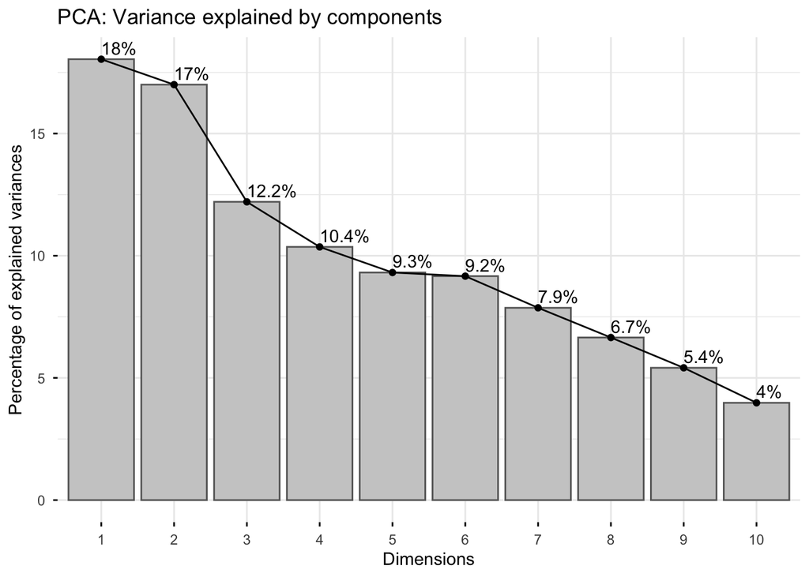

```r
pca_res <- prcomp(X_s, center = FALSE, scale. = FALSE)  # already scaled

# Variance explained (Scree plot)
fviz_eig(pca_res, addlabels = TRUE, barcolor = "gray40", barfill = "gray80") +
  labs(title = "PCA: Variance explained by components")
```

```r
# Compute proportion of variance explained
var_explained <- pca_res$sdev^2 / sum(pca_res$sdev^2)

# Cumulative proportion of variance
cum_var <- cumsum(var_explained)

#  Create data frame for plotting
data.frame(
  PC = 1:length(var_explained),
  Variance = var_explained,
  Cumulative = cum_var
) %>% kbl2(digits = 3)
```

| PC | Variance | Cumulative |
| --- | --- | --- |
| 1 | 0.180 | 0.180 |
| 2 | 0.170 | 0.350 |
| 3 | 0.122 | 0.472 |
| 4 | 0.104 | 0.576 |
| 5 | 0.093 | 0.669 |
| 6 | 0.092 | 0.761 |
| 7 | 0.079 | 0.840 |
| 8 | 0.067 | 0.906 |
| 9 | 0.054 | 0.960 |
| 10 | 0.040 | 1.000 |

```r
K <- which(cum_var >= 0.9)[1]
cat("Keeping", K, "components explains ≥90% of variance.\n")
```

```
## Keeping 8 components explains ≥90% of variance.
```

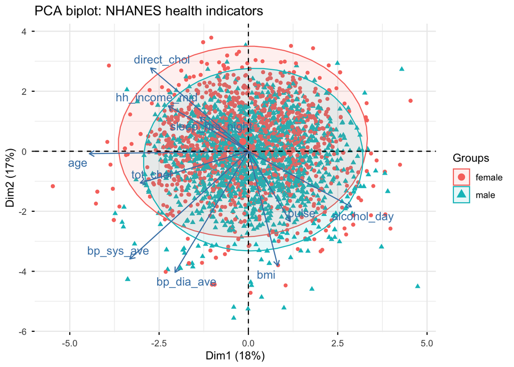

```r
X_pca_auto <- as.data.frame(pca_res$x[, 1:K])

# Biplot by gender for a quick view (color any group you prefer)
fviz_pca_biplot(
  pca_res,
  geom.ind = "point",
  habillage = nhanes_tr$gender, addEllipses = TRUE, repel = TRUE
) + labs(title = "PCA biplot: NHANES health indicators")
```

## PCA scores (for modeling or clustering):

```r
pc_scores <- as.data.frame(predict(pca_res, newdata = X_s))
head(pc_scores)
```

[output not shown]

**Projecting new data:** use `predict(pca_res, newdata = X_new_scaled)`.

⸻

## PCA loadings

```r
loadings_df <- data.frame(variable = rownames(pca_res$rotation), unclass(pca_res$rotation))
# View all loadings
pca_res$rotation[,1:3] %>% kbl2(digits = 3)
```

|  | PC1 | PC2 | PC3 |
| --- | --- | --- | --- |
| age | -0.536 | -0.010 | 0.345 |
| bmi | 0.099 | -0.473 | 0.383 |
| bp_sys_ave | -0.400 | -0.445 | 0.055 |
| bp_dia_ave | -0.247 | -0.500 | -0.225 |
| tot_chol | -0.365 | -0.131 | -0.395 |
| direct_chol | -0.330 | 0.344 | -0.471 |
| pulse | 0.141 | -0.290 | -0.425 |
| sleep_hrs_night | -0.164 | 0.141 | 0.008 |
| hh_income_mid | -0.270 | 0.188 | 0.013 |
| alcohol_day | 0.347 | -0.230 | -0.348 |

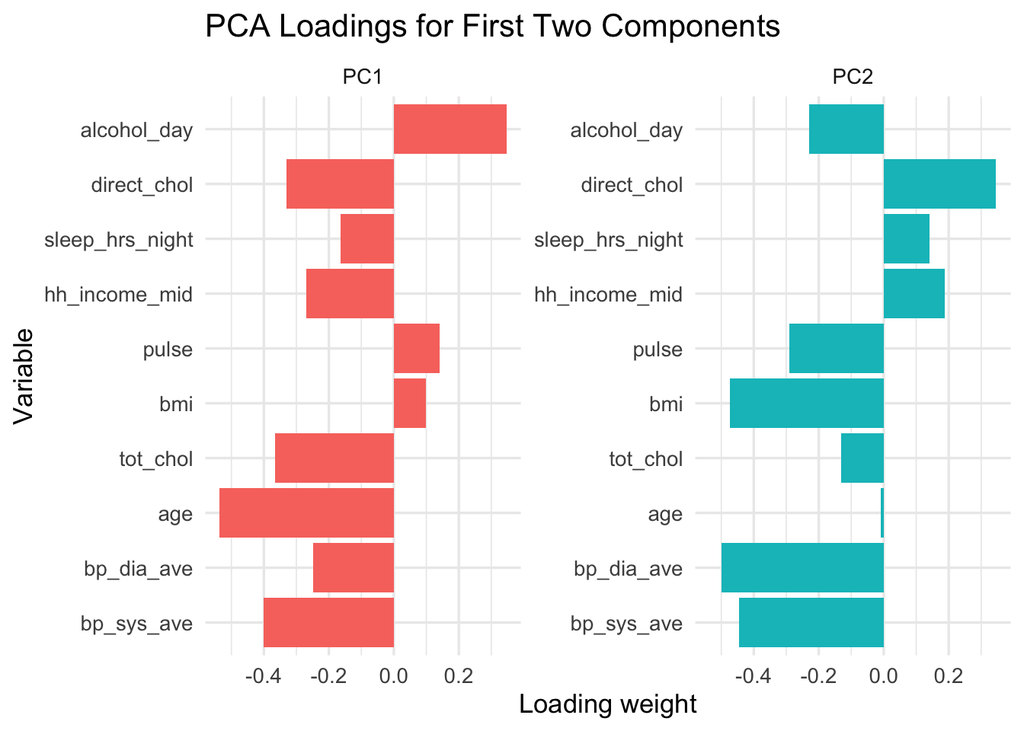

```r
loadings_df %>%
  pivot_longer(cols = starts_with("PC"), names_to = "Component", values_to = "Loading") %>%
  filter(Component %in% c("PC1", "PC2")) %>%
  ggplot(aes(x = reorder(variable, Loading), y = Loading, fill = Component)) +
  geom_col(show.legend = FALSE) +
  facet_wrap(~ Component, scales = "free_y") +
  coord_flip() +
  theme_minimal(base_size = 13) +
  labs(title = "PCA Loadings for First Two Components",
       x = "Variable", y = "Loading weight")
```

• A large positive or negative loading means that variable contributes strongly to that component.

• Signs can flip depending on conventions — only the relative magnitude matters.

⸻

## Varimax Rotation

The `stats::varimax()` function can be applied to the loadings matrix (columns = components).

```r
# Apply varimax rotation to the first 3 components
rotated <- varimax(pca_res$rotation[, 1:3])

# Extract rotated loadings
rotated$loadings[1:10,1:3] %>% kbl2(digits = 3)
```

|  | PC1 | PC2 | PC3 |
| --- | --- | --- | --- |
| age | -0.588 | -0.242 | 0.047 |
| bmi | -0.019 | -0.187 | 0.587 |
| bp_sys_ave | -0.163 | -0.560 | 0.144 |
| bp_dia_ave | 0.141 | -0.584 | 0.033 |
| tot_chol | 0.045 | -0.428 | -0.348 |
| direct_chol | -0.041 | -0.074 | -0.665 |
| pulse | 0.467 | -0.245 | -0.083 |
| sleep_hrs_night | -0.165 | 0.007 | -0.139 |
| hh_income_mid | -0.258 | -0.022 | -0.204 |
| alcohol_day | 0.540 | -0.053 | 0.017 |

⸻

Compare Before and After

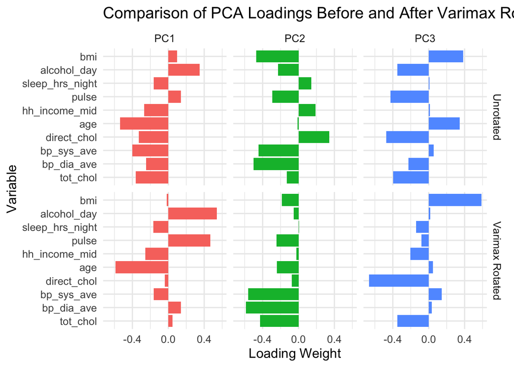

```r
load_unrotated <- as.data.frame(pca_res$rotation[, 1:3]) %>%
  mutate(variable = rownames(.)) %>%
  pivot_longer(cols = starts_with("PC"), names_to = "Component", values_to = "Loading") %>%
  mutate(type = "Unrotated")

load_rotated <- as.data.frame(rotated$loadings[, 1:3]) %>%
  mutate(variable = rownames(.)) %>%
  pivot_longer(cols = starts_with("PC"), names_to = "Component", values_to = "Loading") %>%
  mutate(type = "Varimax Rotated")

loadings_df <- rbind(load_unrotated, load_rotated)


ggplot(loadings_df, aes(x = reorder(variable, Loading), y = Loading, fill = Component)) +
  geom_col(show.legend = FALSE) +
  facet_grid(type ~ Component, scales = "free_y") +
  coord_flip() +
  theme_minimal(base_size = 13) +
  labs(title = "Comparison of PCA Loadings Before and After Varimax Rotation",
       x = "Variable", y = "Loading Weight")
```

⸻

# 2) Factor Analysis (FA)

Factor Analysis (FA) seeks to identify a smaller number of **latent factors** that explain the correlations among observed variables.  
Unlike PCA, which summarizes total variance, FA focuses on **shared variance**—what variables have in common.

For example, in a public health dataset, one latent factor might represent *“cardio-metabolic risk”* (capturing BMI, blood pressure, and cholesterol), while another could represent *“behavioral/lifestyle risk”* (capturing sleep, alcohol, and physical activity).

## Step 1: Assess Suitability

Before performing FA, we verify that variables are sufficiently correlated to justify it.  
Two common checks are the **Kaiser-Meyer-Olkin (KMO)** measure and **Bartlett’s test of sphericity**.

```r
library(psych)

# KMO > 0.6 is acceptable; closer to 1 is better
psych::KMO(X_s)$MSA
```

```
## [1] 0.5276732
```

```r
# Bartlett's test (tests whether correlation matrix differs from identity)
psych::cortest.bartlett(cor(X_s), n = nrow(X_s))
```

```
## $chisq
## [1] 4149.037
##
## $p.value
## [1] 0
##
## $df
## [1] 45
```

## Step 2: Determine the Number of Factors

A parallel analysis compares observed eigenvalues to those from random data to help decide how many factors to retain.

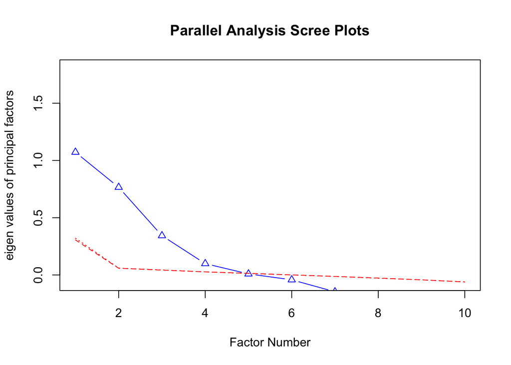

```
## Parallel analysis suggests that the number of factors =  4  and the number of components =  NA
```

```r
fa.parallel(X_s, fa = "fa", n.iter = 50, show.legend = FALSE)
```

• The number of factors where the observed eigenvalue line drops below the simulated one indicates the cutoff.

• Typically, we retain factors before that point (often 2–4 in health datasets).

## Step 3: Fit the Factor Analysis Model

```r
fa_fit <- fa(X_s, nfactors = 2, rotate = "varimax", fm = "ml")
print(fa_fit, sort = TRUE)
```

```
## Factor Analysis using method =  ml
## Call: fa(r = X_s, nfactors = 2, rotate = "varimax", fm = "ml")
## Standardized loadings (pattern matrix) based upon correlation matrix
##                 item   ML1   ML2    h2   u2 com
## bp_sys_ave         3  0.81  0.00 0.663 0.34 1.0
## bp_dia_ave         4  0.51 -0.24 0.318 0.68 1.4
## tot_chol           5  0.22  0.12 0.062 0.94 1.5
## age                1  0.43  0.60 0.552 0.45 1.8
## alcohol_day       10 -0.01 -0.47 0.222 0.78 1.0
## direct_chol        6 -0.02  0.32 0.104 0.90 1.0
## pulse              7  0.04 -0.29 0.087 0.91 1.0
## hh_income_mid      9  0.00  0.22 0.050 0.95 1.0
## bmi                2  0.20 -0.22 0.088 0.91 2.0
## sleep_hrs_night    8  0.00  0.14 0.021 0.98 1.0
##
##                        ML1  ML2
## SS loadings           1.20 0.97
## Proportion Var        0.12 0.10
## Cumulative Var        0.12 0.22
## Proportion Explained  0.55 0.45
## Cumulative Proportion 0.55 1.00
##
## Mean item complexity =  1.3
## Test of the hypothesis that 2 factors are sufficient.
##
## df null model =  45  with the objective function =  0.99 with Chi Square =  4149.04
## df of  the model are 26  and the objective function was  0.3
##
## The root mean square of the residuals (RMSR) is  0.07
## The df corrected root mean square of the residuals is  0.09
##
## The harmonic n.obs is  4217 with the empirical chi square  1779.24  with prob <  0
## The total n.obs was  4217  with Likelihood Chi Square =  1256.43  with prob <  1.2e-248
##
## Tucker Lewis Index of factoring reliability =  0.481
## RMSEA index =  0.106  and the 90 % confidence intervals are  0.101 0.111
## BIC =  1039.41
## Fit based upon off diagonal values = 0.78
## Measures of factor score adequacy
##                                                    ML1  ML2
## Correlation of (regression) scores with factors   0.86 0.77
## Multiple R square of scores with factors          0.74 0.60
## Minimum correlation of possible factor scores     0.48 0.20
```

Factor loadings represent the correlation between each observed variable and the latent factor.

• Loadings close to +1 or −1 indicate a strong relationship.

• Loadings near 0 suggest weak or no relationship.

• Signs indicate the direction of association, not “good” or “bad.”

You can view and sort loadings directly:

```r
loadings_df <- as.data.frame(unclass(fa_fit$loadings))
loadings_df %>% kbl2(digits = 3)
```

|  | ML1 | ML2 |
| --- | --- | --- |
| age | 0.432 | 0.605 |
| bmi | 0.202 | -0.218 |
| bp_sys_ave | 0.814 | 0.000 |
| bp_dia_ave | 0.512 | -0.236 |
| tot_chol | 0.219 | 0.119 |
| direct_chol | -0.017 | 0.322 |
| pulse | 0.040 | -0.293 |
| sleep_hrs_night | -0.001 | 0.144 |
| hh_income_mid | -0.005 | 0.223 |
| alcohol_day | -0.008 | -0.471 |

• Factor 1 has high loadings on BPsys, and BPdia → call it “Cardio-metabolic risk.”

• Factor 2 has high loadings on age, AlcoholDay → call it “Age.”

Factor scores represent each participant’s value on the latent constructs.

```r
fa_scores <- as.data.frame(fa_fit$scores) %>% setNames(c("FA1", "FA2"))
head(fa_scores)  %>% kbl2(digits = 3)
```

| FA1 | FA2 |
| --- | --- |
| -0.066 | -0.042 |
| -0.241 | 0.521 |
| -0.241 | 0.521 |
| -0.241 | 0.521 |
| -0.297 | 0.921 |
| -0.524 | 0.489 |

You can then use these scores in regression models, clustering, or prediction tasks — they summarize the original correlated variables into smaller, interpretable dimensions.

⸻

# 3) Independent Component Analysis (ICA)

ICA attempts to find **statistically independent** components rather than uncorrelated ones (like PCA).  
It’s useful when signals (e.g., EEG, fMRI, or mixed biological measurements) are thought to arise from independent sources.

We’ll use the same dataset `X_s` (scaled continuous variables from NHANES).

```r
ica_fit <- fastICA(X_s, n.comp = 3)

# Get independent component scores
ica_scores <- data.frame(ica_fit$S, X_s)
colnames(ica_scores)[1:3] <- paste0("IC", 1:3)

# Add identifiers
ica_scores$id <- 1:nrow(X_s)

# Show highest and lowest scorers on IC1
extreme_ica <- ica_scores |>
  arrange(IC1) |>
  slice(c(1:3, (n()-2):n()))

extreme_ica %>% kbl2(digits = 2)
```

| IC1 | IC2 | IC3 | age | bmi | bp_sys_ave | bp_dia_ave | tot_chol | direct_chol | pulse | sleep_hrs_night | hh_income_mid | alcohol_day | id |
| --- | --- | --- | --- | --- | --- | --- | --- | --- | --- | --- | --- | --- | --- |
| -4.24 | -0.28 | 0.50 | 0.28 | 3.05 | 2.86 | 2.80 | 0.91 | -0.56 | 0.69 | -0.63 | -4.02 | 0.38 | 2577 |
| -4.03 | -0.10 | 0.24 | -0.59 | 1.83 | 2.48 | 3.64 | 0.32 | -2.97 | 0.34 | 0.15 | 0.72 | 1.98 | 3395 |
| -3.94 | -1.60 | -1.29 | -0.59 | 1.31 | 2.11 | 3.05 | 0.55 | -0.93 | 1.57 | -2.60 | -0.71 | 3.46 | 2455 |
| 2.83 | -0.06 | 0.82 | 0.40 | -1.69 | -1.12 | -1.78 | 0.91 | 1.27 | -2.12 | 0.83 | 0.89 | -1.00 | 454 |
| 2.83 | -0.06 | 0.82 | 0.40 | -1.69 | -1.12 | -1.78 | 0.91 | 1.27 | -2.12 | 0.83 | 0.89 | -1.00 | 455 |
| 2.84 | 1.60 | 1.40 | 2.15 | -1.37 | 0.87 | -6.02 | 0.78 | 0.10 | -1.07 | 0.15 | 0.21 | -1.00 | 1203 |

**Interpretation:** These are the individuals whose data reflect the most negative and most positive expression of the first independent component — in a health context, this might correspond to distinct behavioral or physiological profiles.

Now, find people with similar IC1 scores (local structure):

```r
# Find two participants with closest IC1 scores
similar_ica <- ica_scores |>
  mutate(diff = abs(IC1 - median(IC1))) |>
  arrange(diff) |>
  slice(1:3)

similar_ica %>% kbl2(digits = 2)
```

| IC1 | IC2 | IC3 | age | bmi | bp_sys_ave | bp_dia_ave | tot_chol | direct_chol | pulse | sleep_hrs_night | hh_income_mid | alcohol_day | id | diff |
| --- | --- | --- | --- | --- | --- | --- | --- | --- | --- | --- | --- | --- | --- | --- |
| 0.05 | 0.06 | 0.17 | -1.16 | 0.09 | 0.18 | 0.59 | -0.07 | -0.17 | -0.37 | 0.15 | 0.89 | -1 | 2827 | 0 |
| 0.05 | 0.06 | 0.17 | -1.16 | 0.09 | 0.18 | 0.59 | -0.07 | -0.17 | -0.37 | 0.15 | 0.89 | -1 | 2828 | 0 |
| 0.05 | 0.06 | 0.17 | -1.16 | 0.09 | 0.18 | 0.59 | -0.07 | -0.17 | -0.37 | 0.15 | 0.89 | -1 | 2829 | 0 |

⸻

# 4) Multidimensional Scaling (MDS)

MDS focuses on preserving pairwise distances among individuals. It gives a geometric representation of similarity.

```r
dist_mat <- dist(X_s)
mds_fit <- cmdscale(dist_mat, k = 2, eig = TRUE)
mds_scores <- data.frame(mds_fit$points, X_s)
colnames(mds_scores)[1:2] <- c("Dim1", "Dim2")
mds_scores$id <- 1:nrow(X_s)

# Identify extreme and similar cases
extreme_mds <- mds_scores |> arrange(Dim1) |> slice(c(1:3, (n()-2):n())) |> group_by(Dim1) |> filter(row_number() == 1)
similar_mds <- mds_scores |> mutate(diff = abs(Dim1 - median(Dim1))) |> arrange(diff) |> slice(c(1:3, (n()-2):n())) |> group_by(age) |> filter(row_number() == 1)

extreme_mds %>% kbl2(digits = 2)
```

| Dim1 | Dim2 | age | bmi | bp_sys_ave | bp_dia_ave | tot_chol | direct_chol | pulse | sleep_hrs_night | hh_income_mid | alcohol_day | id |
| --- | --- | --- | --- | --- | --- | --- | --- | --- | --- | --- | --- | --- |
| -5.48 | 1.16 | 2.09 | -0.94 | 3.42 | 2.29 | 2.09 | 2.71 | 0.34 | 0.83 | 0.89 | -1.00 | 3371 |
| 4.54 | -1.68 | -1.28 | -1.10 | -1.37 | -1.44 | -5.07 | -1.47 | -1.07 | -1.54 | -2.55 | -0.19 | 3169 |
| 4.74 | 4.51 | -1.03 | 3.15 | -0.63 | -0.17 | 0.65 | -1.63 | 2.45 | -2.60 | -1.09 | 6.38 | 2229 |

```r
similar_mds %>% kbl2(digits = 2)
```

| Dim1 | Dim2 | age | bmi | bp_sys_ave | bp_dia_ave | tot_chol | direct_chol | pulse | sleep_hrs_night | hh_income_mid | alcohol_day | id | diff |
| --- | --- | --- | --- | --- | --- | --- | --- | --- | --- | --- | --- | --- | --- |
| -0.03 | 2.73 | -1.03 | 1.68 | 1.67 | 1.27 | 0.53 | -1.07 | 0.51 | 0.83 | -0.03 | 0.38 | 344 | 0.00 |
| -0.03 | -2.93 | -0.22 | -1.31 | -2.06 | -1.36 | 0.75 | 0.80 | -0.54 | 0.15 | 0.72 | -1.00 | 723 | 0.00 |
| -5.48 | 1.16 | 2.09 | -0.94 | 3.42 | 2.29 | 2.09 | 2.71 | 0.34 | 0.83 | 0.89 | -1.00 | 3371 | 5.44 |

The first dimension (Dim1) captures the strongest pattern in pairwise similarity — individuals on opposite ends have very different overall health profiles, while those near each other are highly similar.

⸻

# 5) t-SNE

t-SNE preserves local neighborhoods — it’s designed to bring together individuals who are similar across many features.

```r
set.seed(42)
# Need to remove any duplicates before running t-SNE
X_unique <- as.data.frame(X_s) %>% distinct()

message("Removed ", nrow(X_s) - nrow(X_unique), " duplicate rows.")

tsne_fit <- Rtsne(X_unique, dims = 2, perplexity = 40, verbose = FALSE)
tsne_scores <- data.frame(tsne_fit$Y,  X_unique)
colnames(tsne_scores)[1:2] <- c("Dim1", "Dim2")
tsne_scores$id <- 1:nrow(X_unique)

# Find extremes and neighbors
extreme_tsne <- tsne_scores |> arrange(Dim1) |> slice(1:8) |> group_by(age) |> filter(row_number() == 1)
similar_tsne <- tsne_scores |> mutate(diff = abs(Dim1 - median(Dim1))) |> arrange(diff) |> slice(1:8) |> group_by(age) |> filter(row_number() == 1)

extreme_tsne %>% kbl2(digits = 2)
```

| Dim1 | Dim2 | age | bmi | bp_sys_ave | bp_dia_ave | tot_chol | direct_chol | pulse | sleep_hrs_night | hh_income_mid | alcohol_day | id |
| --- | --- | --- | --- | --- | --- | --- | --- | --- | --- | --- | --- | --- |
| -26.97 | -7.11 | 0.90 | -0.50 | 1.61 | 0.93 | -2.58 | -1.01 | -0.19 | -1.54 | -1.43 | 0.38 | 2122 |
| -26.60 | -6.29 | 1.15 | 0.60 | 1.74 | 0.76 | -2.27 | -1.56 | 0.34 | 0.15 | -0.33 | 0.38 | 424 |
| -26.45 | -5.31 | 0.09 | 0.71 | 1.74 | 0.51 | -1.48 | -0.93 | -1.07 | 0.83 | -0.71 | -0.19 | 1249 |
| -26.40 | -5.35 | 0.28 | -0.34 | 2.11 | 0.59 | -1.38 | -1.16 | -0.01 | 0.83 | -1.43 | -0.19 | 1270 |
| -25.69 | -10.30 | 1.22 | 1.83 | 0.99 | -1.44 | -1.58 | 0.63 | 2.45 | 1.45 | -1.09 | 0.38 | 1425 |
| -25.14 | -6.20 | 1.71 | -0.46 | 2.67 | -0.51 | -0.23 | -1.89 | -0.89 | 0.83 | -1.87 | 0.82 | 868 |
| -25.07 | -2.52 | 1.34 | -0.78 | 4.72 | 1.86 | -0.98 | 1.42 | 1.04 | 0.15 | -1.87 | 2.38 | 992 |

```r
similar_tsne %>% kbl2(digits = 2)
```

| Dim1 | Dim2 | age | bmi | bp_sys_ave | bp_dia_ave | tot_chol | direct_chol | pulse | sleep_hrs_night | hh_income_mid | alcohol_day | id | diff |
| --- | --- | --- | --- | --- | --- | --- | --- | --- | --- | --- | --- | --- | --- |
| 0.32 | 2.19 | -0.22 | -0.23 | -0.19 | 0.93 | 0.20 | 0.10 | 1.22 | 0.83 | 0.21 | -0.19 | 2473 | 0.00 |
| 0.32 | -5.97 | -0.78 | -0.45 | -0.19 | 0.17 | 0.48 | 1.37 | -0.72 | 0.15 | 0.72 | -0.19 | 752 | 0.00 |
| 0.32 | 1.27 | -0.66 | 0.11 | 0.06 | 0.76 | -0.29 | 0.52 | -0.01 | 2.01 | 0.72 | -0.19 | 190 | 0.00 |
| 0.32 | -5.99 | -0.59 | 0.04 | -0.32 | -0.17 | -0.15 | 0.73 | -0.89 | 0.15 | 0.89 | -0.19 | 754 | 0.00 |
| 0.33 | 9.19 | -0.16 | 0.64 | 0.74 | 0.59 | -0.42 | -1.07 | 0.16 | 0.15 | 0.89 | -0.19 | 552 | 0.01 |
| 0.31 | -9.49 | 0.15 | -1.20 | -1.31 | -0.85 | 0.22 | 2.24 | -1.42 | 0.15 | 0.89 | -0.19 | 710 | 0.01 |
| 0.34 | 15.71 | -1.09 | 0.68 | 1.12 | 1.52 | 0.55 | 0.02 | 1.22 | -0.63 | 0.72 | 1.48 | 106 | 0.02 |
| 0.34 | 17.88 | 0.47 | -0.91 | 1.36 | -0.34 | 0.46 | -0.05 | 2.80 | -0.63 | 0.42 | 0.82 | 2595 | 0.02 |

⸻

# 6) UMAP

UMAP, like t-SNE, preserves local structure, but also does better at maintaining some global context.

```r
set.seed(42)
umap_fit <- umap(X_s)
umap_scores <- data.frame(umap_fit[,1:2], X_s)
colnames(umap_scores)[1:2] <- c("Dim1", "Dim2")
umap_scores$id <- 1:nrow(X_s)

# Find extremes and neighbors
extreme_umap <- umap_scores |> arrange(Dim2) |> slice(1:10) |> group_by(age) |> filter(row_number() == 1)
similar_umap <- umap_scores |> mutate(diff = abs(Dim1 - median(Dim1))) |> arrange(diff) |> slice(1:9) |> group_by(age) |> filter(row_number() == 1)

extreme_umap %>% kbl2(digits = 2)
```

| Dim1 | Dim2 | age | bmi | bp_sys_ave | bp_dia_ave | tot_chol | direct_chol | pulse | sleep_hrs_night | hh_income_mid | alcohol_day | id |
| --- | --- | --- | --- | --- | --- | --- | --- | --- | --- | --- | --- | --- |
| -3.01 | -10.16 | -0.91 | 3.66 | -1.06 | -0.68 | 0.91 | 1.33 | 2.45 | -0.63 | 0.42 | 0.38 | 261 |
| -3.01 | -10.16 | -0.59 | 1.63 | -0.94 | -1.61 | 1.48 | 0.63 | 2.09 | -0.63 | 0.89 | 0.38 | 1647 |
| -3.01 | -10.16 | -0.53 | 2.40 | 0.37 | -1.27 | 1.32 | 1.11 | 2.27 | -0.63 | 0.42 | -0.19 | 3811 |
| 2.48 | -6.94 | -0.34 | 0.05 | -1.06 | -0.85 | 2.18 | -2.35 | -1.24 | -0.63 | -1.09 | -0.19 | 555 |

```r
similar_umap %>% kbl2(digits = 2)
```

| Dim1 | Dim2 | age | bmi | bp_sys_ave | bp_dia_ave | tot_chol | direct_chol | pulse | sleep_hrs_night | hh_income_mid | alcohol_day | id | diff |
| --- | --- | --- | --- | --- | --- | --- | --- | --- | --- | --- | --- | --- | --- |
| 0.03 | -3.29 | -1.47 | -1.69 | -0.44 | -0.17 | -2.06 | -0.56 | -1.24 | 0.83 | -2.55 | 0.38 | 3762 | 0 |
| 0.03 | 4.58 | 1.59 | -0.76 | 0.56 | 0.59 | -0.83 | 1.37 | -1.42 | -0.63 | -0.71 | -1.00 | 183 | 0 |
| 0.03 | -2.55 | -0.34 | -1.63 | -0.32 | 0.25 | -0.15 | -0.05 | 2.62 | 0.15 | -1.87 | -0.19 | 2463 | 0 |
| 0.03 | -2.51 | -0.59 | -0.19 | -1.19 | -0.17 | 0.65 | -0.65 | -0.72 | 0.83 | -2.55 | -1.00 | 707 | 0 |
| 0.03 | -4.16 | -1.03 | -0.70 | -0.87 | -2.38 | -0.83 | -0.35 | -0.89 | 2.51 | -0.71 | 1.98 | 845 | 0 |
| 0.04 | 1.81 | -0.53 | -0.15 | 1.92 | -0.43 | 0.42 | 0.15 | -0.37 | 0.15 | 0.89 | -0.19 | 3539 | 0 |
| 0.04 | -4.16 | -1.34 | -0.86 | -0.81 | -1.27 | -2.32 | -0.10 | -0.72 | 1.45 | -1.09 | 1.98 | 656 | 0 |
| 0.04 | -3.75 | -1.53 | -0.55 | 0.43 | -0.93 | -0.44 | -0.30 | -0.89 | 0.83 | -0.71 | 0.82 | 1107 | 0 |

We can use the model with `umap_transform()` – with the same centering/scaling – to predict for new data.

**UMAP vs t-SNE:**

• UMAP retains more of the large-scale structure (distance between groups still roughly meaningful).

• t-SNE zooms in on fine-scale neighborhoods — good for cluster visualization.

• Both methods show smooth transitions in the “embedding” space.

⸻

Practical Guidance & Method Selection

• PCA (global, linear projection):

- *Pros:* interpretable loadings; stable; easy to use in regression/ML pipelines; projectable to new data.
- *Use when:* you want compact, reproducible features and global structure.

• FA (latent constructs):

- *Pros:* interpretable latent factors; models shared covariance.
- *Use when:* you hypothesize underlying constructs (e.g., “cardio-metabolic risk”).

• ICA (independence):

- *Pros:* separates independent signals; useful in biomedical signal processing.
- *Use when:* looking for statistically independent patterns (exploratory).

• MDS (global distances):

- *Pros:* preserves pairwise global geometry.
- *Caveat:* no straightforward projection for new data.

• t-SNE (local neighborhoods):

- *Pros:* reveals clusters/subgroups; great for visualization.
- *Caveat:* not a projection; sensitive to settings; don’t interpret global distances.

• UMAP (local + some global):

- *Pros:* fast; often clearer cluster structure; transform available via uwot.
- *Caveat:* embedding can vary with hyperparameters; still primarily for visualization.

⸻

Appendix: Reproducibility Notes

• Centering/Scaling: save the means/SDs and reapply to new data.

• PCA/FA/ICA for modeling: save fitted objects; apply same transforms to holdout or future data.

• Local methods (t-SNE/MDS): use for visualization/exploration; avoid as features in regression unless you know the implications.

• UMAP (uwot) can transform new data: more convenient than t-SNE/MDS but still not as stable/interpretable as PCA/FA.

```r
# Example: capture scaling parameters and PCA for later use
scale_center <- attr(X_s, "scaled:center")
scale_scale  <- attr(X_s, "scaled:scale")
# saveRDS(list(center = scale_center, scale = scale_scale, pca = pca_res), "pca_artifacts.rds")
```